# Stat 202: Lecture 1 (covers pp. 1-21)

Nathan VanHoudnos  
9/24/2014

### Statistics 202 - Welcome

- Nathan VanHoudnos (van-HOD-ness)
  - [http://www.stat.cmu.edu/~nmv](http://www.stat.cmu.edu/%7Enmv)
- Order of business today:
  - Go over the syllabus (10 minutes)
  - Lecture proper (30 minutes)
  - Orientation to course software (10 minutes)

### The Big Picture of Statistics 202

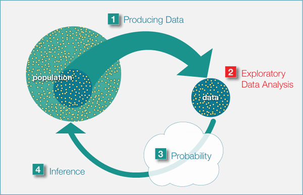

### BRFSS: Behavioral Risk Factor Surveillance System

- is an annual telephone survey of people living the United states.
- seeks to identify individual-level behavioral risk factors associated with premature mortality and morbidity.
  - e.g. cigarette smoking, alcohol use …
- collected 491,773 records in 2013.
- further info / full data available [from the CDC](http://www.cdc.gov/brfss/).
- a 20,000 record is subset available from [Lab 1](http://www.openintro.org/stat/labs.php?stat_book=os) of the [OpenIntro Statistics](http://www.openintro.org/) course.

### Definitions

- **Data:** pieces of information organized into variables
  - **Individuals:** particular persons or objects
  - **Variables:** particular characteristics of individuals
- Two Types of Variables
  - **Quantitative** represent numerical measurements
    - e.g. Age, Weight, and Height
  - **Categorical** represent categories or labels
    - e.g. Race, Gender, and Level of Education

### Categorical or Quantitative?

- Would you say that in general your health is Excellent, Very Good, Good, Fair or Poor ?
  - Categorical
- Have you smoked at least 100 cigarettes in your entire life?
  - Categorical
- On average, how many hours of sleep do you get in a 24-hour period?
  - Quantitative
- What is the ZIP Code where you live?
  - Categorical

### BRFSS Example Data

| genhlth | age | gender | height | weight | wtdesire |
| --- | --- | --- | --- | --- | --- |
| good | 45 | f | 64.00 | 120 | 110 |
| good | 77 | m | 70.00 | 175 | 175 |
| very good | 32 | f | 61.00 | 115 | 105 |
| excellent | 44 | f | 67.00 | 190 | 165 |
| poor | 52 | f | 63.00 | 142 | 120 |
| very good | 27 | f | 64.00 | 105 | 120 |
| very good | 18 | f | 63.00 | 140 | 130 |
| very good | 46 | f | 64.00 | 148 | 120 |
| fair | 27 | f | 60.00 | 115 | 115 |
| very good | 31 | m | 71.00 | 194 | 185 |

### Summarizing Categorical Variables

- **genhlth** Would you say that in general your health is excellent, very good, good, fair, or poor?
  - A table of raw counts:

    | excellent | very good | good | fair | poor | Sum |
    | --- | --- | --- | --- | --- | --- |
    | 4,657 | 6,972 | 5,675 | 2,019 | 677 | 20,000 |

  - A table of proportions:

    | excellent | very good | good | fair | poor | Sum |
    | --- | --- | --- | --- | --- | --- |
    | 0.23 | 0.35 | 0.28 | 0.10 | 0.03 | 1.00 |

### Visualizing Categorical Data

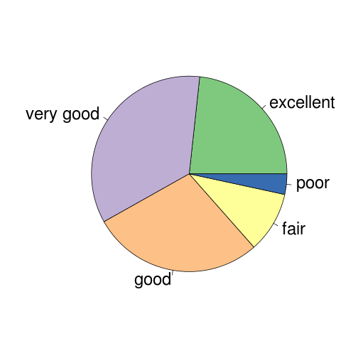

**Mode:** most common value that occurs.

What is the modal response?

- “Very Good”

That was harder than it needed to be…

### Visualizing Categorical Data

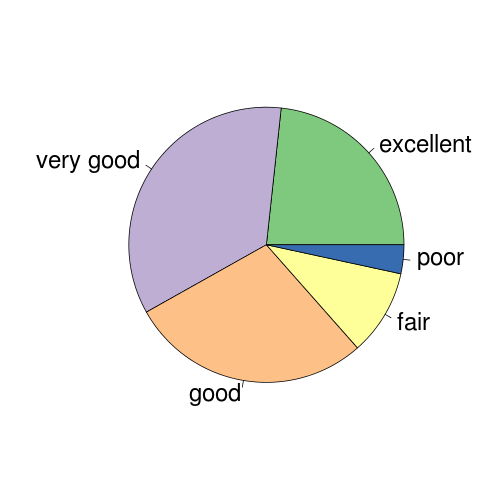

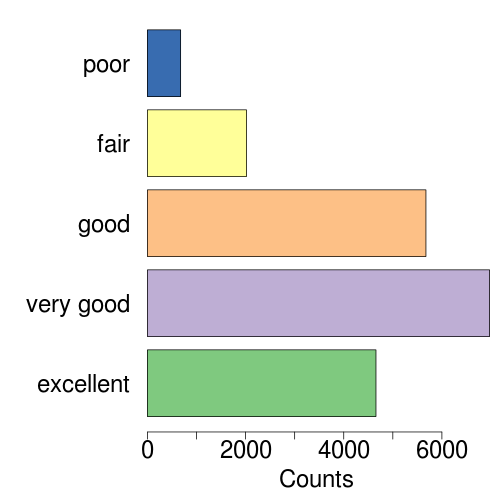

### BRFSS Example Data

| genhlth | age | gender | height | weight | wtdesire |
| --- | --- | --- | --- | --- | --- |
| good | 45 | f | 64.00 | 120 | 110 |
| good | 77 | m | 70.00 | 175 | 175 |
| very good | 32 | f | 61.00 | 115 | 105 |
| excellent | 44 | f | 67.00 | 190 | 165 |
| poor | 52 | f | 63.00 | 142 | 120 |
| very good | 27 | f | 64.00 | 105 | 120 |
| very good | 18 | f | 63.00 | 140 | 130 |
| very good | 46 | f | 64.00 | 148 | 120 |
| fair | 27 | f | 60.00 | 115 | 115 |
| very good | 31 | m | 71.00 | 194 | 185 |

### Visualizing Quantitative Variables

| Ranges | Frequency |
| --- | --- |
| 45-50 | 4 |
| 50-55 | 18 |
| 55-60 | 871 |
| 60-65 | 6,464 |
| 65-70 | 7,899 |
| 70-75 | 4,399 |
| 75-80 | 337 |
| 80-85 | 7 |
| 85-90 | 0 |
| 90-95 | 1 |

**Histogram:** analog of a bar plot

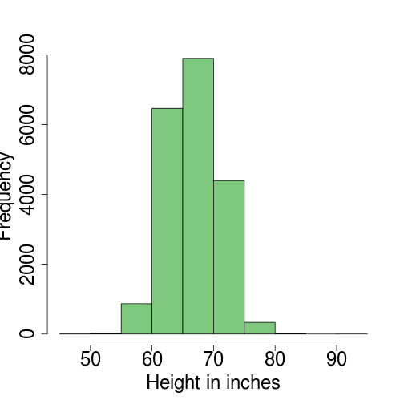

### Interpreting Quantitative Variables

**Histogram**

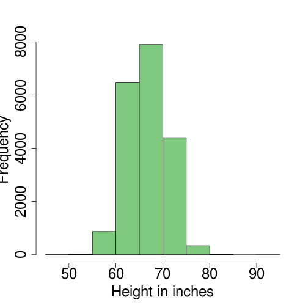

1. Describe the shape
2. Describe the center
3. Describe the spread
4. Note deviations from the pattern

### Shapes of Quantitative Variables

**Symmetric:** balanced on both sides

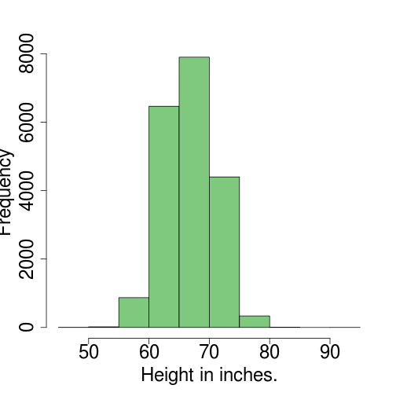

**Skewed:** one tail is longer than the other

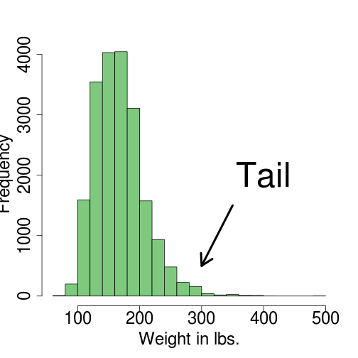

### Shapes of Quantitative Variables

**Unimodal:** one peak

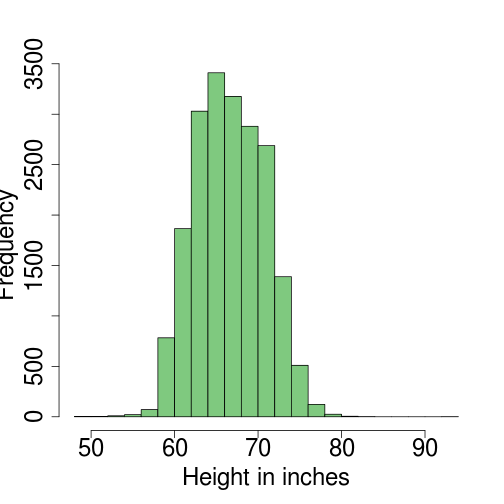

**Bimodal:** two peaks

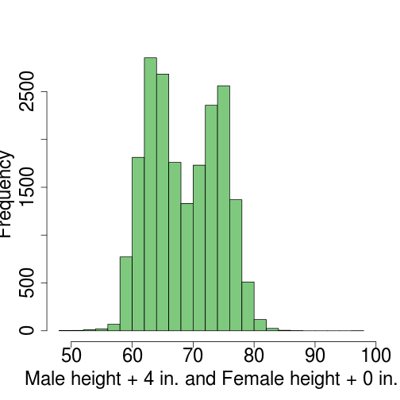

### Shapes of Quantitative Variables

**Uniform:** flat, no apparent modes

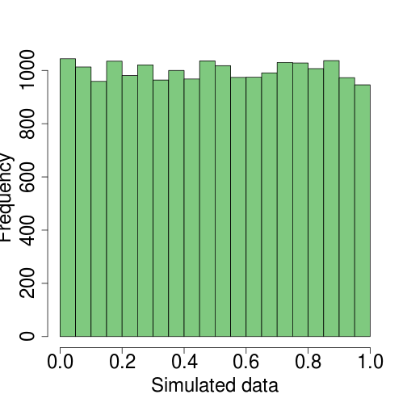

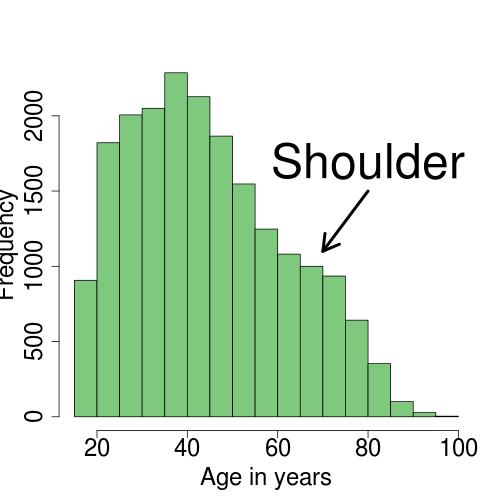

### Interpreting Shape

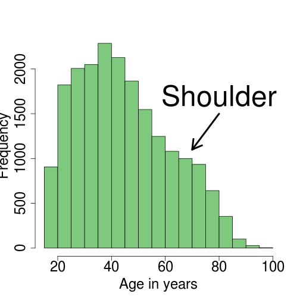

Variables with bimodal distributions are usually mixtures of two groups.

What group might be represented by the shoulder?

- [Baby boomers](http://en.wikipedia.org/wiki/Baby_boomers)

### Best Actress Oscar Winners

|  | year | age |
| --- | --- | --- |
| 1 | 1970 | 34 |
| 2 | 1971 | 34 |
| 3 | 1972 | 26 |
| 4 | 1973 | 37 |
| 5 | 1974 | 42 |
| 6 | 1975 | 41 |
| 7 | 1976 | 35 |
| 8 | 1977 | 31 |
| 9 | 1978 | 41 |
| 10 | 1979 | 33 |

… etc.

How old was the winner of the Best Actress Oscar at the time she won the award?

Should we make a pie chart, bar chart, or histogram?

- **Histogram** because age is quantitative

### Best Actress Oscar Winners

**Age at Oscar**

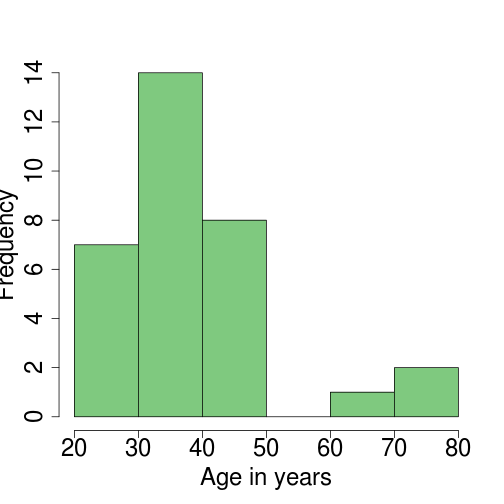

What percent of actresses were older than 60 years?

- Total: 7+14+8+1+2 = 32
- Subset: 1+2 = 3
- Answer:  
  \[ \frac{3}{32} \times 100\% = 9.4\% \]

### Best Actress Oscar Winners

**Age at Oscar**

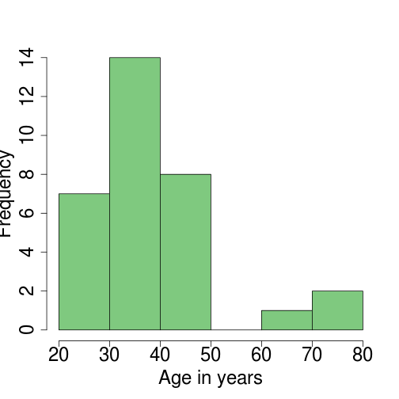

### Small data: Stem-and-leaf plots

**1: Sort Data**

| 21 | 25 | 26 |
| --- | --- | --- |
| 26 | 26 | 29 |
| 30 | 31 | 33 |
| 33 | 33 | 33 |
| 34 | 34 | 34 |
| 35 | 35 | 35 |
| 37 | 38 | 39 |
| 41 | 41 | 41 |
| 42 | 43 | 45 |
| 49 | 49 | 61 |
| 74 | 80 |  |

**2: Split into stems and leaves**

```
  2 | 156669
  3 | 013333444555789
  4 | 11123599
  5 |
  6 | 1
  7 | 4
  8 | 0
```

- resembles a histogram
- preserves and sorts the data
- useful for **small** data sets

### Stem-and-leaf plot: bin size

**Age** w/ bin of 10

```
  2 | 156669
  3 | 013333444555789
  4 | 11123599
  5 |
  6 | 1
  7 | 4
  8 | 0
```

**Age** w/ bin of 5

```
  2 | 1
  2 | 56669
  3 | 013333444
  3 | 555789
  4 | 11123
  4 | 599
  5 |
  5 |
  6 | 1
  6 |
  7 | 4
  7 |
  8 | 0
```

### Interpreting Quantitative Variables

**Age**

```
  2 | 1
  2 | 56669
  3 | 013333444
  3 | 555789
  4 | 11123
  4 | 599
  5 |
  5 |
  6 | 1
  6 |
  7 | 4
  7 |
  8 | 0
```

1. Describe the shape
2. **Describe the center**
3. Describe the spread
4. Note deviations from the pattern

### Measures of center

**Age**

```
  2 | 1
  2 | 56669
  3 | 013333444
  3 | 555789
  4 | 11123
  4 | 599
  5 |
  5 |
  6 | 1
  6 |
  7 | 4
  7 |
  8 | 0
```

- **mean:** the average

```
38.53
```

- **mode:** the most common number

```
33
```

- **median:** the midpoint (half are below it, half above)

```
35
```

### Calculating the median

**Age**

```
  2 | 1
  2 | 56669
  3 | 013333444
  3 | 555789
  4 | 11123
  4 | 599
  5 |
  5 |
  6 | 1
  6 |
  7 | 4
  7 |
  8 | 0
```

- If **n** is odd, then the median is the \( \frac{n+1}{2} \) observation.
- If **n** is even, then the median is the average of \( \frac{n}{2} \) and \( \frac{n}{2} + 1 \) observations
- For these data, n=32
  - The 16<sup>th</sup> obs. is 35
  - The 17<sup>th</sup> obs. is *also* 35
  - the median is 35.

### Median versus Mean

Consider two data sets:

| Data_A | 64 | 65 | 66 | 68 | 70 | 71 | 73 |
| --- | --- | --- | --- | --- | --- | --- | --- |
| Data_B | 64 | 65 | 66 | 68 | 70 | 71 | 730 |

The mean and median of Data A are:

```
Mean: 68.14   Median: 68
```

The mean and median of Data B are:

```
Mean: 162   Median: 68
```

- The mean was **pulled** to the outlier.
- The median was unchanged.

### Oscar age recap

**Age**

```
  2 | 1
  2 | 56669
  3 | 013333444
  3 | 555789
  4 | 11123
  4 | 599
  5 |
  5 |
  6 | 1
  6 |
  7 | 4
  7 |
  8 | 0
```

- **mean:** the average

```
38.53
```

- **median:** the midpoint

```
35
```

- The mean is **less trustworthy** for
  - skewed variables, or
  - variables with outliers.

### Interpreting Quantitative Variables

1. Describe the shape
   - symmetric, right-skewed, or left-skewed
   - unimodal, bimodal, or multimodal
2. Describe the center
   - choose mean or median
3. Describe the spread (**Friday**)
4. Note deviations from the pattern
   - possible outliers

### Order of business today:

- Go over the syllabus (10 minutes)
- Lecture proper (30 minutes)
- Orientation to course software (10 minutes)

### OLI textbook

- Developed as a self-study course by CMU
  - Follows Moore's “Basic Practice of Statistics”
- Additional activities beyond reading:
  - Ungraded: Learn by Doing & Did I get this?
  - Graded: Checkpoint quizzes
- **How to use it:**
  1. Pay attention in lecture.
  2. Do a few ungraded activities.
  3. Study what you miss.
  4. Take the checkpoint quiz **before** next lecture.

### R & RStudio

- Intro stats often limited by **small data**
  - Best Actress Oscar Winners
- Practicing statisticians use **big data**
  - BRFSS (½ million records) is **still** quite small
- This course teaches modern data tools:
  - R is a statistical programming language.
  - RStudio is a useful interface to R.
  - We will **not** be programming! (later courses)

### R Markdown

- R Markdown is a simple way to combine R commands with written text.
  - e.g. this lecture!
- Homeworks will be distributed as R Markdown files (*.rmd)
- Your task is to …
  - complete the R Markdown file with RStudio,
  - **knit** it into an html file, and
  - upload the html file to BlackBoard.
- Demo